# 7th May

Anna Hutchinson

### 1. De-inflation of large P

I have a problem whereby very large $p$-values never reach 1. This occurs whether I am estimating cfdr using either:

1. “kgrid method”: $cFdr=\dfrac{p}{kgrid}=\dfrac{p}{P(P\leq p, Q\leq q)/P(Q\leq q|H0)}$
2. “Bivariate method”: $cFdr=\dfrac{P(P\leq p, Q\leq q|H0)}{P(P\leq p, Q\leq q)}$

Recall that we find the L curves in a two-step approach:

1. Find `ccut=cfdr(p,q)` (note that `ccut` values are identical when using kgrid and bivariate methods)

```r
ccut = interp.surface(cgrid, cbind(zp[indices], q[indices]))
```

2. Construct the L curves by finding the xval2 such that `cfdr(xval2,yval2)=ccut` for each value yval2 takes. [I.e. we build a cfdr curve for each value of yval2 and find the x coordinate (xval2) where the cfdr curve equals ccut].

```r
# "kgrid" method
for (i in 1:length(yval2)) {
  xdenom=interp.surface(kgrid,cbind(xtest,rep(yval2[i],length(xtest))))
  cfx=cummin(ptest/xdenom)
  xval2[,i]=approx(cfx, xtest, ccut, rule=2, method="const", f=1)$y
}

# "bivariate method" (where cgrid is the ratio of two bivariates)
for (i in 1:length(yval2)) {
  xdenom=interp.surface(cgrid,cbind(xtest,rep(yval2[i],length(xtest))))
  cfx=xdenom
  xval2[,i]=approx(cfx, xtest, ccut, rule=2, method="const", f=1)$y
}
```

#### Interpolation methods

Note that different interpolation methods are used to read off the cfdr curves; `interp.surface` in the first step to get the `ccut` values, and constant interpolation using `approx` in the second step to generate the L curves. I stick with the `kgrid` method for now, as the results are the same when using the ratio of bivariates.

I investigate the differences in using these two methods (to generate ccut values).

```r
ccut1 = interp.surface(cgrid, cbind(zp[indices], q[indices]))

ccut2 = rep(1, length(p[indices]))
for (i in 1:length(p[indices])){
  xdenom = interp.surface(kgrid, cbind(kpq$x, rep(q[indices[i]], length(kpq$x))))
  cfx = cummin(2*pnorm(-kpq$x)/xdenom)
  ccut2[i] = approx(kpq$x, cfx, zp[indices[i]], rule=2, method="const", f=1)$y
}

ccut3 = rep(1, length(p[indices]))
for (i in 1:length(p[indices])){
  xdenom = interp.surface(cgrid, cbind(kpq$x, rep(q[indices[i]], length(kpq$x))))
  cfx = xdenom
  ccut3[i] = approx(kpq$x, cfx, zp[indices[i]], rule=2, method="const", f=1)$y
}
```

Findings:

1. The ccut values are deinflated when using the for loop method rather than the `interp.surface` method. Perhaps this could be contributing to the de-inflation problem. Could I use the inter.surface method in the final step to prevent the de-inflation. Although this de-inflation is fixed when increasing the resolution of the generated L curves (using `xtest` rather than `kpq$z` - which is what is actually used in the method).
2. Seperating out the `kgrid` step in the for loop doesn’t change the results (`ccut2` and `ccut3` basically the same).
3. By switching `method="const"` to `method="linear"` in `approx` I can get the same results as when using `interp.surface` (makes sense as they are now both dooing linear interpolation).
4. Using left continuous (`f=1` s.t. the right hand point is used) decreases ccut values, using right continuous (`f=0` s.t. the lest hand point is used) increases ccut values.
5. If I increase the resolution s.t. the cfdr curve is defined on `xtest` (length 5000) rather than `kpq$x` (length 500), then the `ccut` values are increased.

```r
ccut4 = rep(1, length(p[indices]))
for (i in 1:length(p[indices])){
  xdenom = interp.surface(kgrid, cbind(xtest, rep(q[indices[i]], length(xtest))))
  cfx = cummin(ptest/xdenom)
  ccut4[i] = approx(xtest, cfx, zp[indices[i]], rule=2, method="const", f=1)$y
}

ccut5 = rep(1, length(p[indices]))
for (i in 1:length(p[indices])){
  xdenom = interp.surface(cgrid, cbind(xtest, rep(q[indices[i]], length(xtest))))
  cfx = xdenom
  ccut5[i] = approx(xtest, cfx, zp[indices[i]], rule=2, method="const", f=1)$y
}
```

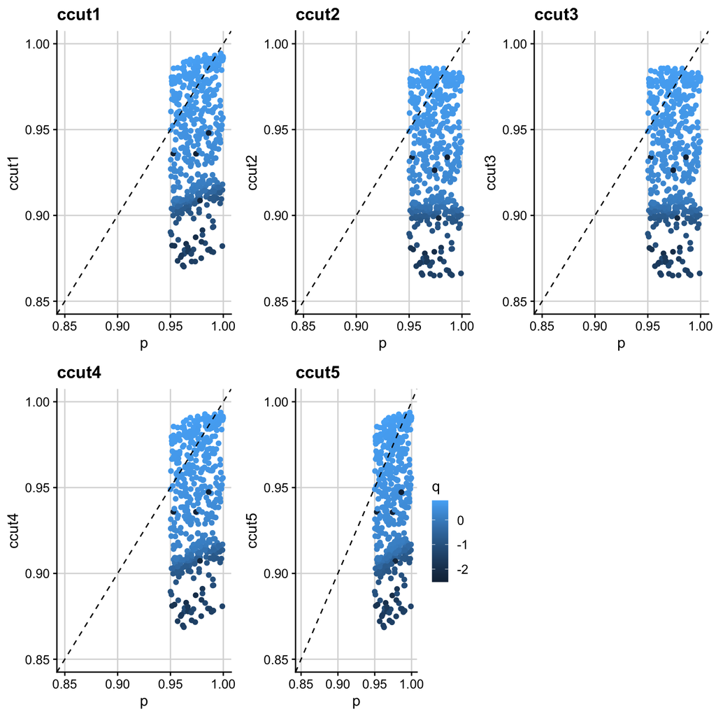

**I think that the same interpolation method should be used to obtain the `ccut` values and the L curve co-ordinates. Why does James choose constant interpolation with left-continuous?**

#### cfdr curve

Upon visual inspection of my cfdr curves, I notice that they do not reach 1, but I think this is correct.

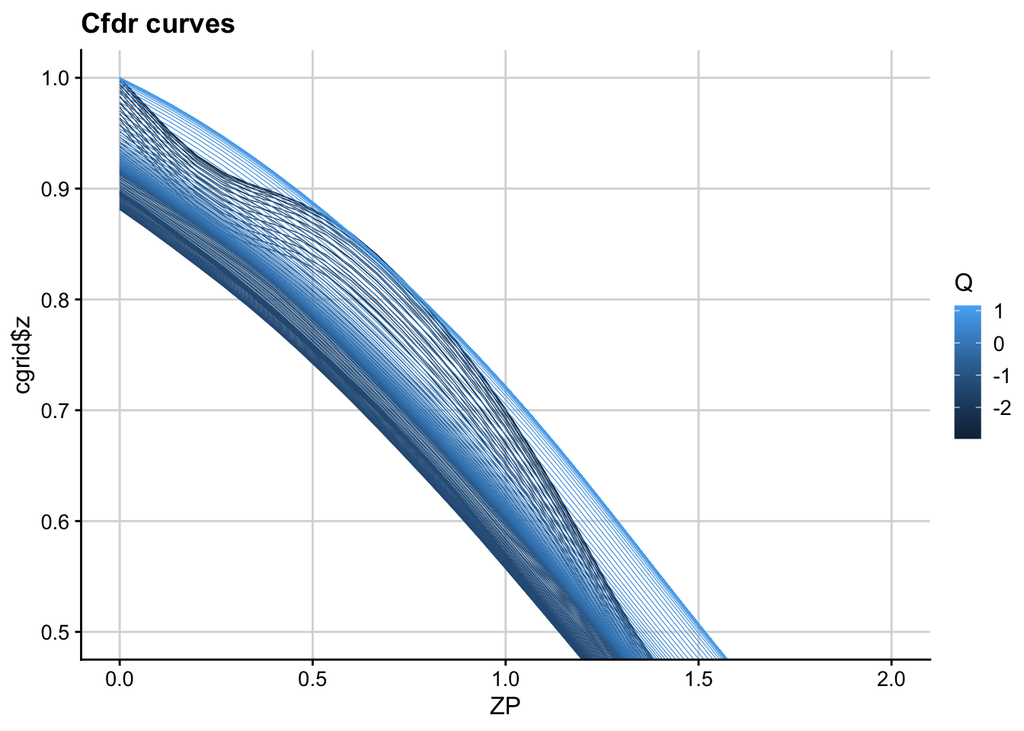

#### L curves

On visual inspection of the L curves for large $p$, they bend inwards for small q, which decreases the area of the L region and may lead to de-inflation (I think it is likely this that is causing the deinflation). Note that this isn’t fixed when fiddling with the `approx` parameters.

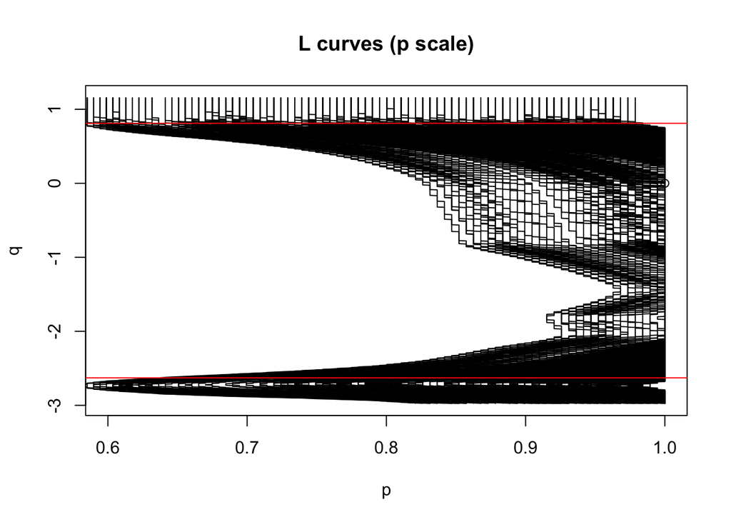

**Why do they bend inwards?**

For each ccut value, the x co-ordinate of the L curve is found by reading off the Z score value where the cfdr curve (at the corresponding y value) equals ccut.

For example ZP is plotted against the cfdr curve for `-0.4978084` below, with a vertical line at a selected ccut value (0.96). Th vertical line doesnt hit the cfdr curve and `rule=2` forces it to take the closest value. The x coordinate of the L curve at this point would therefore be taken to be 0 in these instances (good - no bending inwards):

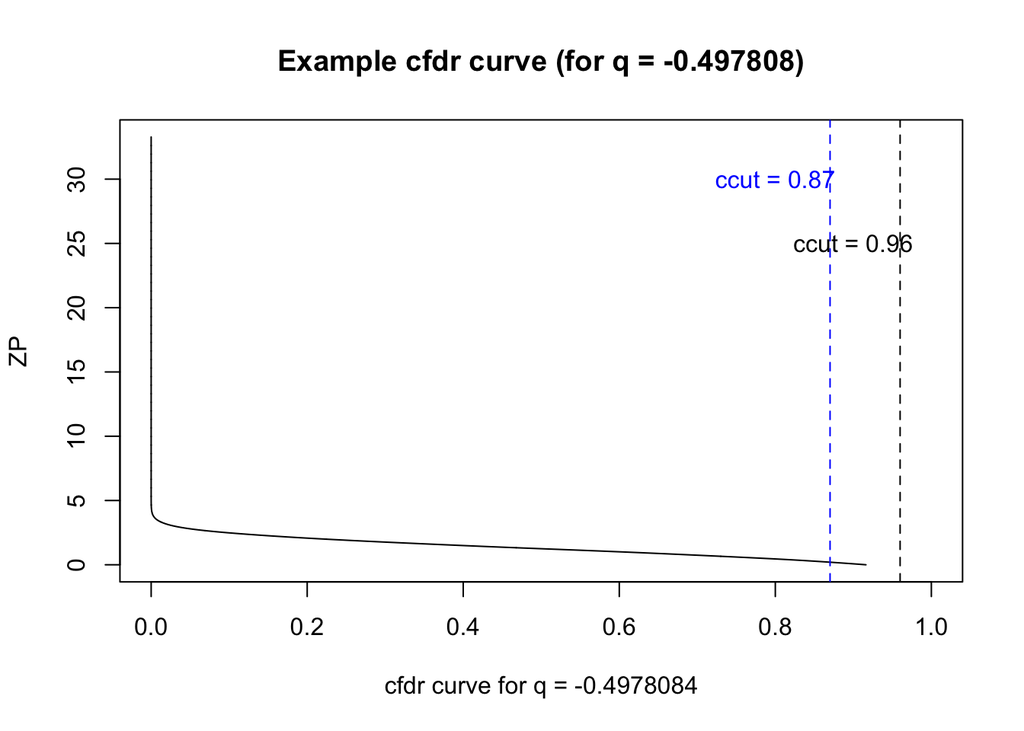

However, if I look at where each of the cfdr curves stop (beyond which x co-ordinates are 0), then we see that the shape exactly reflects the bending of the L curves.

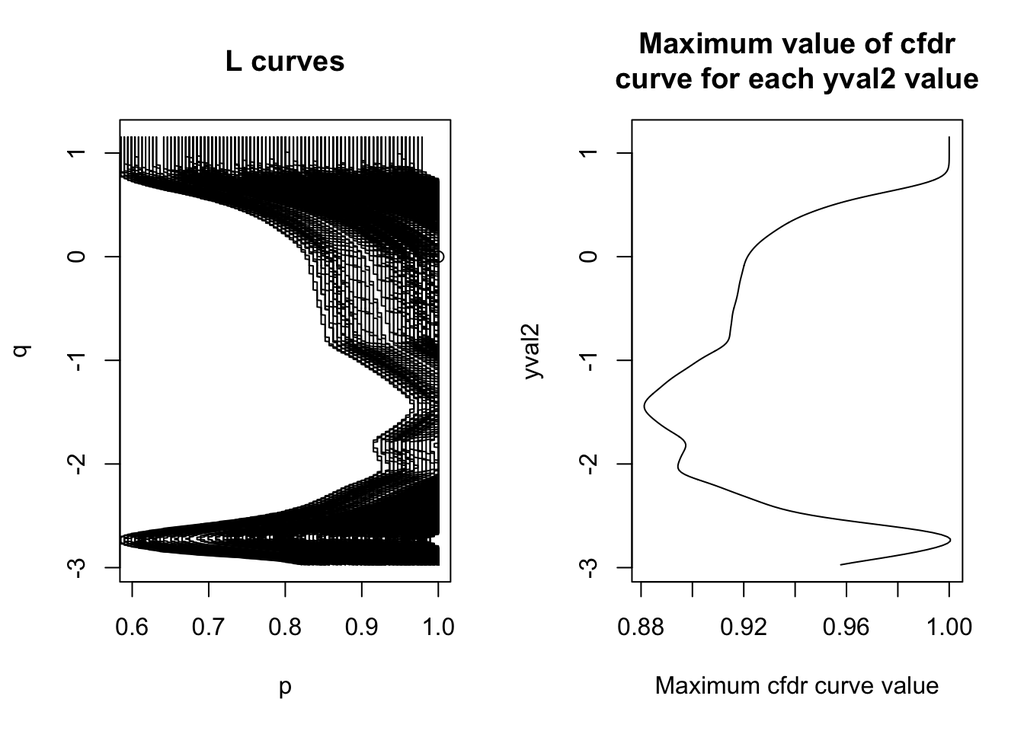

**Can I stop them bending inwards?** (for q < min(q))

For now (as a sort of hack - need a better approach), I stop the extreme bending inwards for $q<min(q)$ by ensuring that cfdr curves are not used for the approximation for small $q$ (since there is not enough data to accurately fit the cfdr curve to read off). Instead, I force them to drop straight downwards.

```r
xval2_new <- outer(rep(1,length(ccut)), yval2)
for (i in 1:length(yval2)) {
  w = which(q[sub] <= rev(yval2)[i])
  if(length(w)>1){
    xdenom=interp.surface(kgrid,cbind(xtest,rep(rev(yval2)[i],length(xtest))))
    cfx= cummin(ptest/xdenom)
    xval2_new[,i]=approx(cfx, xtest, ccut, rule=2, method="const", f=1)$y
  } else if (i>1) xval2_new[,i]=xval2_new[,i-1] else xval2_new[,i]=-qnorm(ccut/2)
}
```

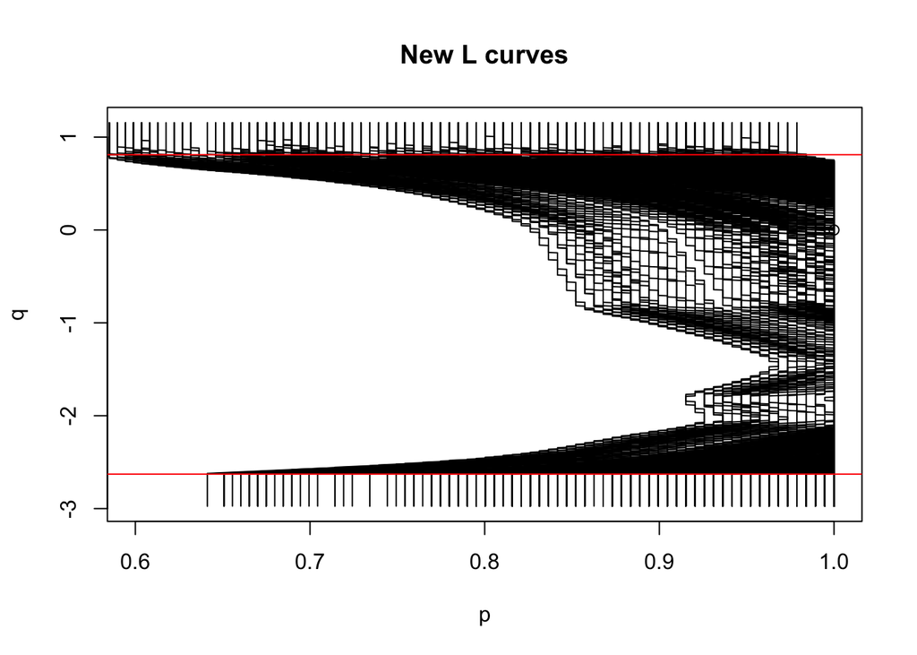

But does this solve the problem? No.

```
## [1] 1.006436
```

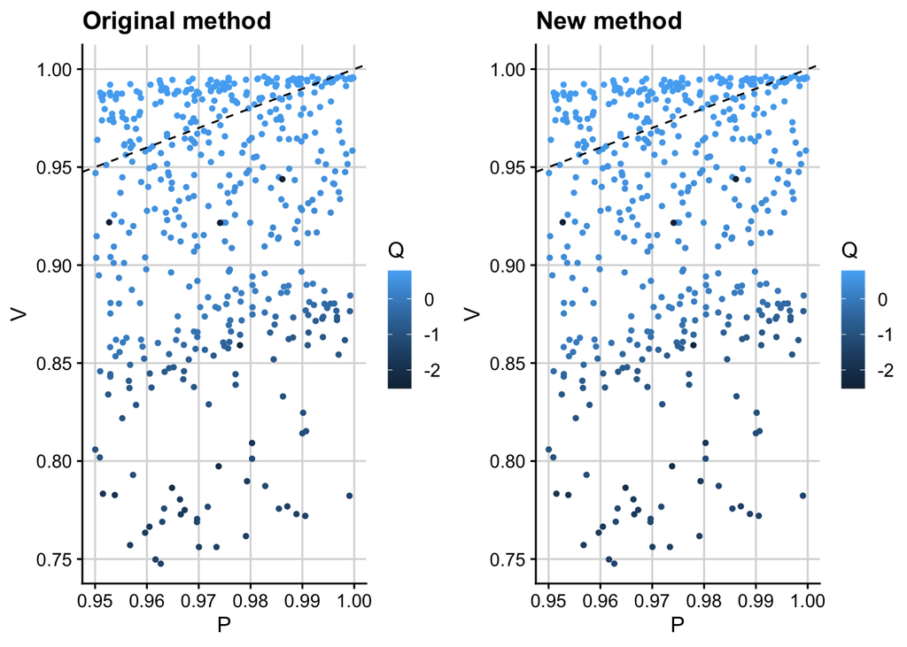

### 2. The story of tailing off

Tailing off of small $p$ values doesn’t occur in my current kgrid method, but it does happen in the bivariate method. It also happens in the kgrid method if I interpolate directly from cgrid in the last step. I investigate why.

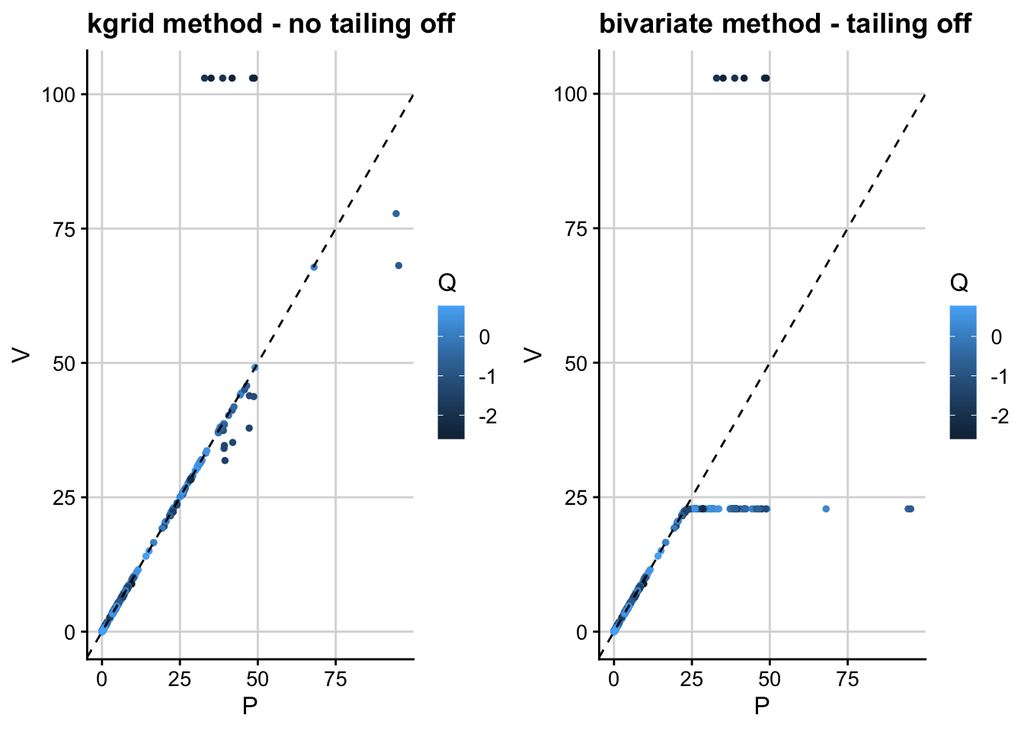

Considering a single index as an example.

If we look at the L curves on the Z score x-axis scale then we see that there is a bulge outwards at approx min(q[sub]) where there is no tailing off (separating out kgrid), as opposed to a bulge inwards where there is tailing off (bivariate method).

On the P value scale this amounts to a nice looking L region for no tailing. For the tailing off example, there is a bulge outwards for low q —> increasing area of L region —> increasing v value —> tailing off.

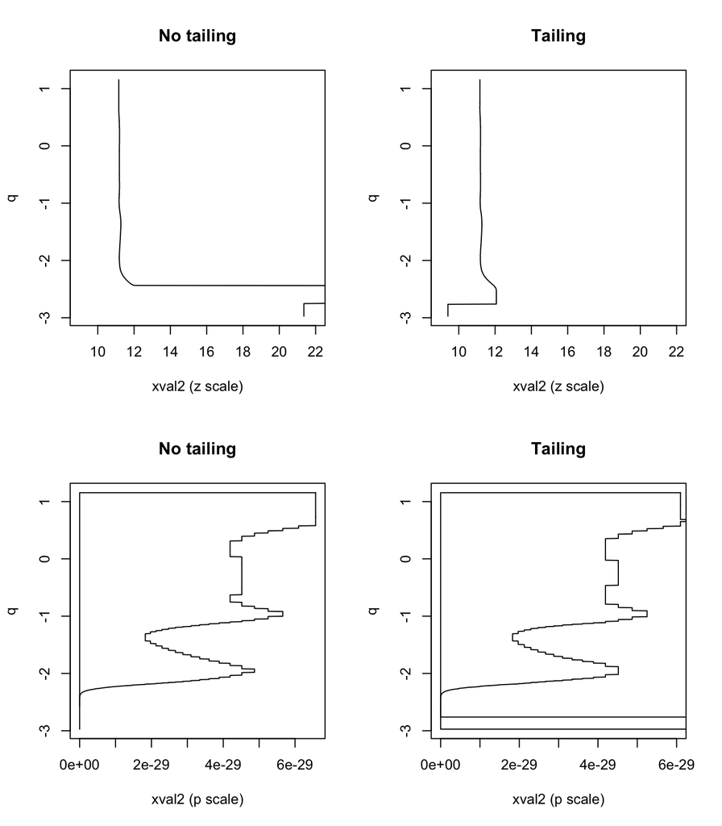

**Why does the bulge appear?**

So it seems to be related to the big P problem whereby we get some unwanted bulging for low q. If I plot the minimum value of cfdr curves for both the kgrid (no tailing) and the bivariate (tailing) methods, then I find that the minimum is always 0 for the bivariate method (meaning that `rule=2` is never used).

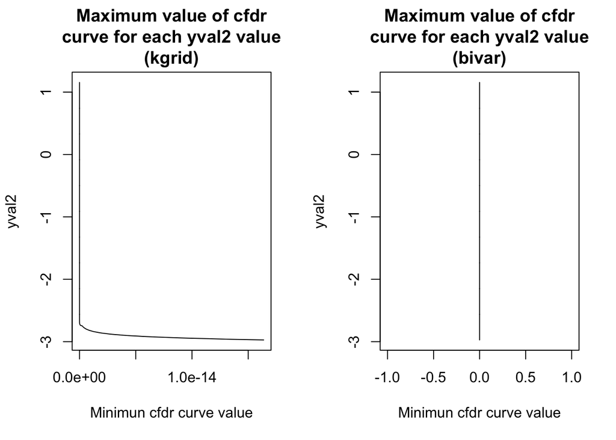

I consider the cfdr curve for yval2=-2.4.. for both methods. Whilst it stops at 8.435309e-26 for the kgrid method (no tailing) it carries on going in the bivariate method.

[figure not shown]

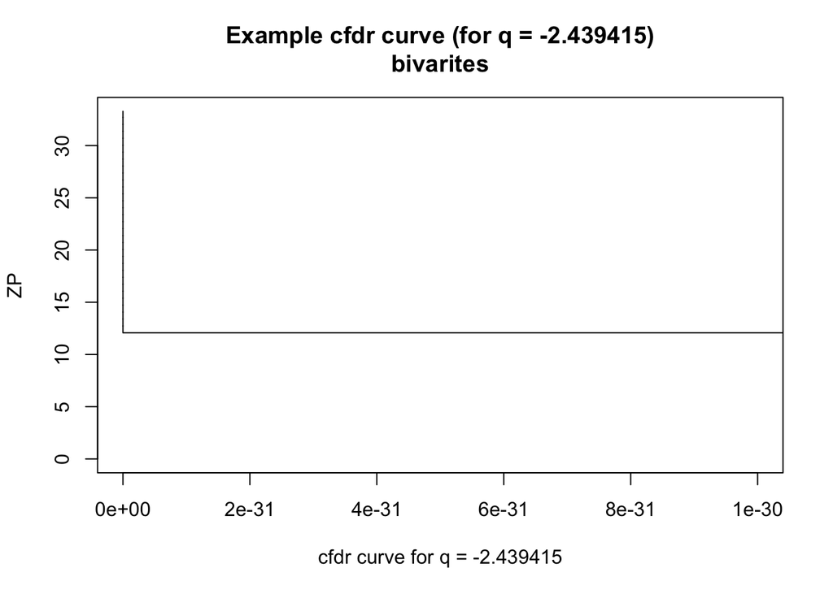

So, using the `rule=2` trick for the cfdr curves (which are not completely defined on $[0,1]$) from the kgrid method seems to solve the problem.

### 3. Full results

The full results for my method (using the hacky big p fix) are shown below.

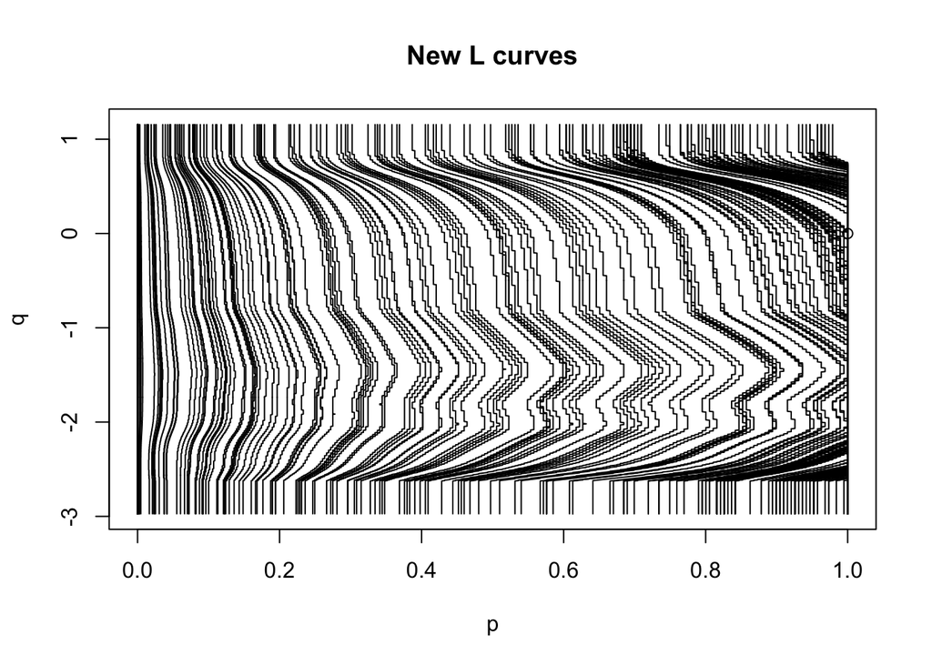

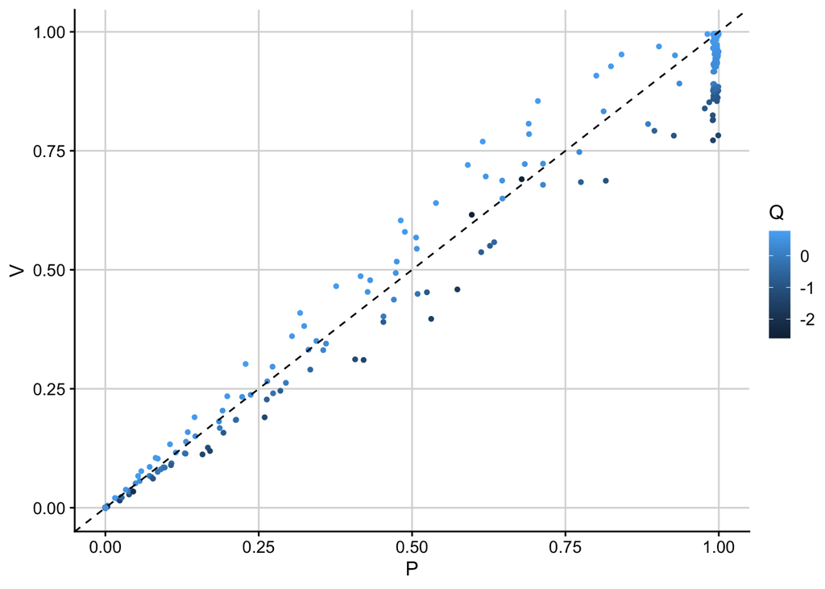

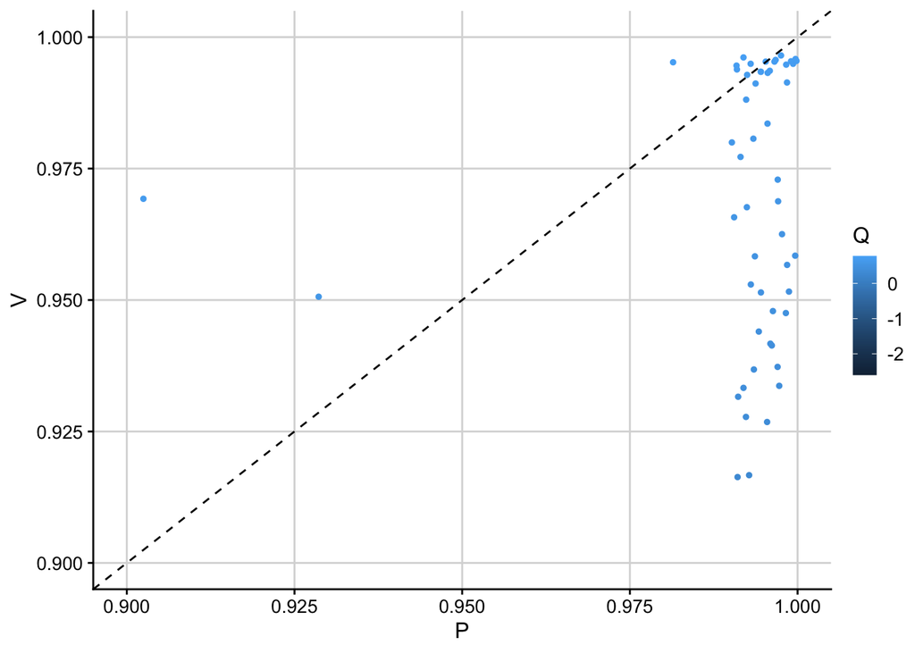

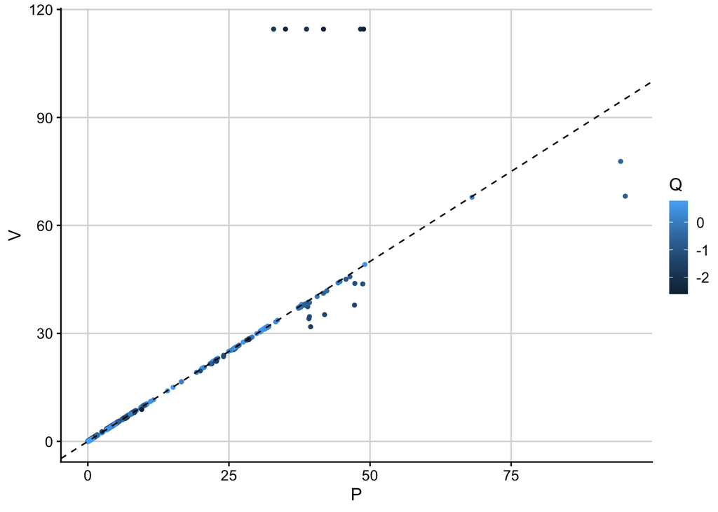